# domaci

```python
import numpy as np
import pandas as pd
import math
```

```python
# Prva linija sadrzi samo rec "Studenti", tako da nju preskacemo.
# Ukoliko rucno pokusamo da otvorimo fajl, mozemo videti da je njegovo kodiranje utf-16. To moramo specifikovati
# ovde, inace se podaci nece lepo ucitati.
data = pd.read_csv('podaci/unm.csv', encoding='utf-16', skiprows=1)

# Metod head() nam vraca prvih pet redova ucitane tabele, sto nam je dovoljno za pregled trenutnog formata.
print(data.head())
```

```
  Бр.\t"Индекс"\t"Име"\t"Презиме"\t"Колоквијуми и тестови 40"\t""\t"Писмено-усмени испит 60"\t""\t"Укупно 100"
0  1.\t" 132/2016"\t"Пеђа"\t"Аврамовић"\t"0"\t""\...
1  2.\t" 104/2016"\t"Лука"\t"Алексић"\t"0"\t""\t"...
2  3.\t" 39/2017"\t"Владимир"\t"Арсенијевић"\t"33...
3  4.\t" 42/2017"\t"Момир"\t"Аџемовић"\t"40"\t" *...
4  5.\t" 77/2017"\t"Марко"\t"Бабић"\t"31"\t""\t"-...
```

```python
print(data.shape)
```

```
(214, 1)
```

```python
data_parsed = pd.read_csv('podaci/unm.csv', encoding='utf-16', skiprows=1, delimiter='\t')
print(data_parsed.head())
```

```
   Бр.     Индекс       Име      Презиме  Колоквијуми и тестови 40 Unnamed: 5  \
0  1.0   132/2016      Пеђа    Аврамовић                       0.0        NaN
1  2.0   104/2016      Лука      Алексић                       0.0        NaN
2  3.0    39/2017  Владимир  Арсенијевић                      33.0        NaN
3  4.0    42/2017     Момир     Аџемовић                      40.0          *
4  5.0    77/2017     Марко        Бабић                      31.0        NaN

  Писмено-усмени испит 60  Unnamed: 7  Укупно 100
0                       -         NaN         0.0
1                       -         NaN         0.0
2                      35         NaN        68.0
3                      55         NaN        95.0
4                       -         NaN        31.0
```

Vidimo da ovde imamo neke prazne kolone. U originalnoj tabeli, to su kolone koje su koriscene za ulepsavanje tabele ili cuvanje nekih dodatnih informacija o studentima (u nasem primeru, to je informacija o tome ko je imao dodatne poene). Kako ove kolone ne nose nikakve informacije od znacaja, mozemo ih odbaciti. Takodje, odbacicemo i prvu kolonu ("Br."), jer vec imamo automatsko indeksiranje tabele. Biblioteka `pandas` nam opet moze pomoci.

```python
# S obzirom da su podaci na cirilici, ovde cemo na nestandardan nacin selektovati potrebne kolone. Generalno,
# sledeci blok koda mogao je biti zamenjen jednostavnim:
# data_new = data_parsed[['Ime', 'Prezime', ...]]

imena_kolona = data_parsed.keys()
potrebne_kolone = imena_kolona[[1,2,3,4,6,8]]
data_clean = data_parsed[potrebne_kolone]
print(data_clean.head())
```

```
      Индекс       Име      Презиме  Колоквијуми и тестови 40  \
0   132/2016      Пеђа    Аврамовић                       0.0
1   104/2016      Лука      Алексић                       0.0
2    39/2017  Владимир  Арсенијевић                      33.0
3    42/2017     Момир     Аџемовић                      40.0
4    77/2017     Марко        Бабић                      31.0

  Писмено-усмени испит 60  Укупно 100
0                       -         0.0
1                       -         0.0
2                      35        68.0
3                      55        95.0
4                       -        31.0
```

Trenutno imamo ociscenu tabelu rezultata ostvarenih na kursu UNM na kraju roka JAN2. Eksportovacemo ovo za eventualnu kasniju obradu, a onda dalje obradjivati podatke, da bismo dobili raspodelu bodova predispitnih i ispitnih obaveza.

```python
data_clean.to_csv('podaci/unm_clean.csv', encoding='utf-16')
```

Sada prelazimo na dalju obradu. Nakon sto smo eksportovali podatke u obliku ocekivanom za nekoga ko ce ih mozda kasnije koristiti, sada mozemo, radi lakse obrade za nas, preimenovati kolone u reci na latinici.

```python
data_clean.columns = ['Indeks', 'Ime', 'Prezime', 'PredispitneObaveze', 'IspitneObaveze', 'Ukupno']
print(data_clean.head())
```

```
      Indeks       Ime      Prezime  PredispitneObaveze IspitneObaveze  Ukupno
0   132/2016      Пеђа    Аврамовић                 0.0              -     0.0
1   104/2016      Лука      Алексић                 0.0              -     0.0
2    39/2017  Владимир  Арсенијевић                33.0             35    68.0
3    42/2017     Момир     Аџемовић                40.0             55    95.0
4    77/2017     Марко        Бабић                31.0              -    31.0
```

Za konstruisanje histograma raspodele poena na predispitnim obavezama, izdvajamo odgovarajucu kolonu u niz.

```python
predispitne = np.array(data_clean['PredispitneObaveze'])
# Uklanjanje eventualnih 'nan' vrednosti.
# isnan(x) vraca indekse svih elemenata koji jesu nan, a '~isnan(x)' komplement toga u skupu indeksa.
predispitne = predispitne[~np.isnan(predispitne)]
print(predispitne)
```

```
[ 0.  0. 33. 40. 31.  9.  0.  0. 19. 40. 40. 13.  7. 15. 11.  0.  7.  0.
 33. 26. 21. 39. 40. 32. 40.  0. 22. 20. 40. 30.  0. 10. 13.  8.  0.  8.
  9.  7.  1. 40.  5. 21. 20. 40. 28.  7.  0.  0. 40. 28. 34. 15. 26.  0.
  0.  0. 11.  3. 18. 20. 34.  0. 15. 14. 12. 33. 24.  0. 13. 38. 30.  7.
  0. 15. 13. 26.  4.  0. 20.  0. 35.  0.  2. 30. 13. 13.  0.  0. 20. 37.
 30. 16. 35. 23. 32.  0. 14. 13. 15. 22. 24.  7.  7. 39. 35.  0.  4. 22.
  0.  0. 23. 40.  8.  0. 16. 15.  0. 22.  9.  5. 40. 19. 30.  0.  7. 23.
 38.  0. 25.  0.  0. 40. 21.  0.  0. 20. 20. 16. 26. 21. 25.  9.  0. 40.
  0.  0. 25. 27.  4. 20.  0. 40.  0. 17.  0.  3. 22.  0. 16.  7. 13.  3.
 27. 28.  5. 40.  7.  0. 13. 16. 31. 35. 39.  0.  3. 10. 18. 25.  0. 24.
 31.  2. 40. 30. 30.  0. 24. 14. 39. 24. 40. 10.  0.  1. 18. 11. 34. 17.
 15. 14. 34. 40. 35. 21.  0.  2. 40. 40. 37.  7.  9. 22.  0.]
```

```python
# Moramo sortirati niz da bismo mogli da napravimo pravilan histogram.
predispitne = np.sort(predispitne)

# Odredjujemo broj podeoka histograma.
duzina = predispitne.size
k = math.floor(math.log(duzina, 2)) + 1
d = (predispitne[duzina - 1] - predispitne[0]) / k
print("Duzina: {0}\nBroj kategorija: {1}\nDuzina podeoka: {2}".format(duzina, k, d))
```

```
Duzina: 213
Broj kategorija: 8
Duzina podeoka: 5.0
```

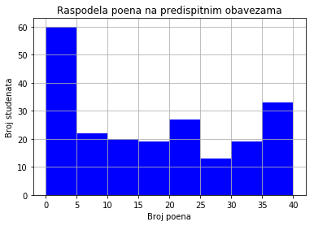

```python
import matplotlib.pyplot as plt

plt.hist(predispitne, bins=k, color='blue')
plt.xlabel('Broj poena')
plt.ylabel('Broj studenata')
plt.title('Raspodela poena na predispitnim obavezama')
plt.grid(True)
# plt.savefig() se mora pozvati pre plt.show(), jer plt.show() "prazni bafer za sliku". Medjutim, posto nam je
# potrebno da samo jednom izgenerisemo sliku, ostavicemo ovu liniju pod komentarom.
# plt.savefig("predispitne.png")
plt.show()
```

```python
# Provera rezultata
print(predispitne[predispitne < 5].size)
```

```
60
```

Sada cemo konstruisati i histogram raspodele poena na ispitu, u rokovima JAN1 i JAN2, zajedno.

```python
ispitne = np.array(data_clean['IspitneObaveze'])
print(ispitne)
```

```
['-' '-' '35' '55' '-' '-' '-' '-' '-' '-' '57' '-' '-' '-' '-' '-' '-'
 '-' '30' '-' '35' '58' '43' '42' '60' '-' '-' '-' '56' '-' '-' '-' '-'
 '-' '-' '-' '-' '-' '-' '-' '-' '-' '44' '58' '35' '-' '-' '-' '35' '36'
 '50' '-' '-' '-' '-' '-' '-' '-' '-' '44' '53' '-' '-' '57' '-' '44' '32'
 '-' '-' '-' '38' '-' '-' '-' '-' '51' '-' '-' '-' '-' '49' '-' '-' '-'
 '-' '-' '-' '-' '-' '32' '-' '-' '-' '-' '-' '-' '-' '-' '36' '-' '-' '-'
 '-' '56' '41' '-' '-' '-' '-' '-' '-' '60' '-' '-' '55' '-' '-' '-' '-'
 '-' '60' '-' '37' '-' '-' '-' '58' '-' '42' '-' '-' '55' '-' '-' '-' '34'
 '37' '-' '49' '-' '-' '-' '-' '-' '-' '-' '-' '-' '-' '-' '-' '54' '-'
 '-' '-' '-' '-' '-' '-' '-' '-' '-' '-' '-' '-' '-' '-' '-' '-' '45' '43'
 '-' '52' '-' '-' '-' '-' '-' '-' '-' '-' '-' '-' '36' '-' '-' '57' '-'
 '59' '-' '43' '-' '-' '-' '-' '-' '50' '-' '-' '-' '35' '-' '-' '-' '-'
 '-' '55' '48' '-' '-' '-' '-' '-' nan]
```

```python
# Ciscenje podataka
ispitne = ispitne[ispitne != '-']
# Zbog karaktera '-' nam je ceo niz konvertovan u karakterski niz, pa cemo ga vratiti nazad u celobrojni
ispitne = pd.to_numeric(ispitne, errors='coerce')
ispitne = ispitne[~np.isnan(ispitne)]
ispitne = np.sort(ispitne)
print(ispitne)
```

```
[30. 32. 32. 34. 35. 35. 35. 35. 35. 36. 36. 36. 37. 37. 38. 41. 42. 42.
 43. 43. 43. 44. 44. 44. 45. 48. 49. 49. 50. 50. 51. 52. 53. 54. 55. 55.
 55. 55. 56. 56. 57. 57. 57. 58. 58. 58. 59. 60. 60. 60.]
```

```
Duzina: 50
Broj kategorija: 6
Duzina podeoka: 5.0
```

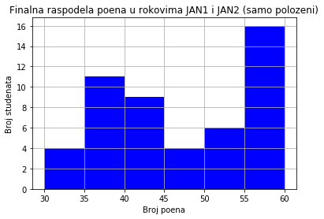

```python
# Odredjujemo broj podeoka histograma.
duzina2 = ispitne.size
k2 = math.floor(math.log(duzina2, 2)) + 1
d2 = (ispitne[duzina2 - 1] - ispitne[0]) / k2
print("Duzina: {0}\nBroj kategorija: {1}\nDuzina podeoka: {2}".format(duzina2, k2, d2))

plt.hist(ispitne, bins=k2, color='blue')
plt.xlabel('Broj poena')
plt.ylabel('Broj studenata')
plt.title('Finalna raspodela poena u rokovima JAN1 i JAN2 (samo polozeni)')
plt.grid(True)
# plt.savefig("jan1_jan2_final.png")
plt.show()
```

Medjutim, ovo je raspodela poena samo onih studenata koji su polozili ispit. Sakupljanjem podataka sa sajtova asistenata, dobili smo podatke o rokovima JAN1 i JAN2 pojedinacno, ali samo za pismeni ispit. Odvojene ukupne rezultate, kao i podatke za studente koji nisu polozili, nije bilo moguce dobiti. U nastavku prilazem raspodelu poena na pismenim ispitima u JAN1 i JAN2 odvojeno, i time zavrsavam ovaj domaci.

```python
# U roku JAN2, asistentkinja Jelena je pregledala obe grupe radova.
jan1_jelena = np.array([19, 14, 14, 12, 16, 18, 6, 4, 17, 14, 10, 15, 18, 17, 18, 5, 0])
jan2_jelena_marija = np.array([13, 7, 16, 12, 18, 18, 16, 20, 12, 14, 15, 14, 7, 17, 15, 14, 12, 10, 13, 8, 8, 11, 5, 17, 15, 15])
jan1_marija = np.array([0, 18, 11, 1, 7, 11, 16, 14, 5, 19, 13, 11, 12, 10])
jan1_dusan = np.array([13, 18, 4, 14, 12, 13, 5, 10, 10, 15, 0, 14, 18, 11, 12])
jan2_dusan = np.array([15, 10, 13, 19, 10, 19, 14, 12, 15, 11, 19, 14, 10, 16, 12, 13])

jan1 = np.sort(np.concatenate((jan1_jelena, jan1_marija, jan1_dusan)))
jan2 = np.sort(np.concatenate((jan2_jelena_marija, jan2_dusan)))
print("JAN1: ", jan1)
print("JAN2: ", jan2)
```

```
JAN1:  [ 0  0  0  1  4  4  5  5  5  6  7 10 10 10 10 11 11 11 11 12 12 12 12 13
 13 13 14 14 14 14 14 14 15 15 16 16 17 17 18 18 18 18 18 18 19 19]
JAN2:  [ 5  7  7  8  8 10 10 10 10 11 11 12 12 12 12 12 13 13 13 13 14 14 14 14
 14 15 15 15 15 15 15 16 16 16 17 17 18 18 19 19 19 20]
```

```
Duzina: 46
Broj kategorija: 6
Duzina podeoka: 3.1666666666666665
```

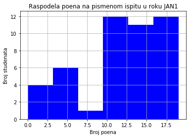

```python
# Odredjujemo broj podeoka histograma.
duzina3 = jan1.size
k3 = math.floor(math.log(duzina3, 2)) + 1
d3 = (jan1[duzina3 - 1] - jan1[0]) / k3
print("Duzina: {0}\nBroj kategorija: {1}\nDuzina podeoka: {2}".format(duzina3, k3, d3))

plt.hist(jan1, bins=k3, color='blue')
plt.xlabel('Broj poena')
plt.ylabel('Broj studenata')
plt.title('Raspodela poena na pismenom ispitu u roku JAN1')
plt.grid(True)
# plt.savefig("jan1_pismeni.png")
plt.show()
```

```
Duzina: 42
Broj kategorija: 6
Duzina podeoka: 2.5
```

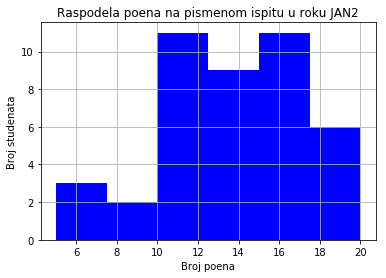

```python
# Odredjujemo broj podeoka histograma.
duzina4 = jan2.size
k4 = math.floor(math.log(duzina4, 2)) + 1
d4 = (jan2[duzina4 - 1] - jan2[0]) / k4
print("Duzina: {0}\nBroj kategorija: {1}\nDuzina podeoka: {2}".format(duzina4, k4, d4))

plt.hist(jan2, bins=k4, color='blue')
plt.xlabel('Broj poena')
plt.ylabel('Broj studenata')
plt.title('Raspodela poena na pismenom ispitu u roku JAN2')
plt.grid(True)
# plt.savefig("jan2_pismeni.png")
plt.show()
```